# Tutorial- simple linear regression example

# Instructions

In this tutorial you will be asked to run some code to load a CSV file (data), do a scatter plot, calculate a correlation coefficient and fit a linear regression. Data and an R script to do this have been provided in this project. This file provides some background and further explanation of the script.

# Cricket chirps

The data, obtained from [college.cengage.com](https://college.cengage.com/mathematics/brase/understandable_statistics/7e/students/datasets/slr/frames/frame.html), relates the rate of cricket chirps to temperature from *The Song of Insects*, by Dr. G. W. Pierce, Harvard College Press.

In this example we’re looking at the relationship between the count of chirps per minute and temperature.

## Load the data

The data are already saved in the project as “chirps.csv”. To load the data into R and show the first few rows, use the following commands.

```r
mydta <- read.csv("chirps.csv")

head(mydta)
```

```
##   Chirps.Minute Temperature
## 1          20.0        88.6
## 2          16.0        71.6
## 3          19.8        93.3
## 4          18.4        84.3
## 5          17.1        80.6
## 6          15.5        75.2
```

## Plot the data

We next run code to create a scatter plot.

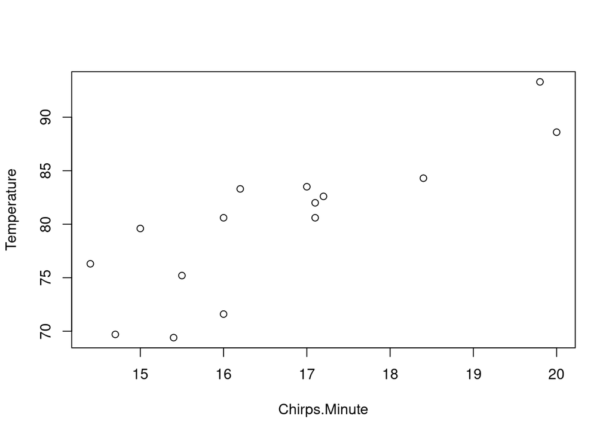

```r
plot(mydta)
```

When you run this the chart is shown in a graphics window.

If we want to save this as a PNG file, for example to put into a Word document, then we may do so as follows.

```r
png("plot1.png")

plot(mydta)

dev.off()
```

After running this the chart will be saved in the project folder.

## Correlation

What is Pearson’s estimated correlation coefficient?

```r
cor.test(mydta[,1], mydta[,2])
```

```
##
##  Pearson's product-moment correlation
##
## data:  mydta[, 1] and mydta[, 2]
## t = 5.4745, df = 13, p-value = 0.0001067
## alternative hypothesis: true correlation is not equal to 0
## 95 percent confidence interval:
##  0.5642928 0.9436856
## sample estimates:
##       cor
## 0.8351438
```

## Linear regression

Fitting the data means plotting all the points, then drawing the best-fit line through that data. The regression line is of the form `y = a + b*x`, where b is the coefficient or slope of the line, and a is the intercept of the line at x=0.

When the following code is run the output of a linear regression in R is printed.

```r
mylm<-lm(Temperature~Chirps.Minute, mydta)

summary(mylm)
```

```
##
## Call:
## lm(formula = Temperature ~ Chirps.Minute, data = mydta)
##
## Residuals:
##    Min     1Q Median     3Q    Max
## -6.515 -1.971  0.490  2.807  5.001
##
## Coefficients:
##               Estimate Std. Error t value Pr(>|t|)
## (Intercept)    25.2323    10.0601   2.508 0.026183 *
## Chirps.Minute   3.2911     0.6012   5.475 0.000107 ***
## ---
## Signif. codes:  0 '***' 0.001 '**' 0.01 '*' 0.05 '.' 0.1 ' ' 1
##
## Residual standard error: 3.829 on 13 degrees of freedom
## Multiple R-squared:  0.6975, Adjusted R-squared:  0.6742
## F-statistic: 29.97 on 1 and 13 DF,  p-value: 0.0001067
```

Visually, the fitted regression line looks like this:

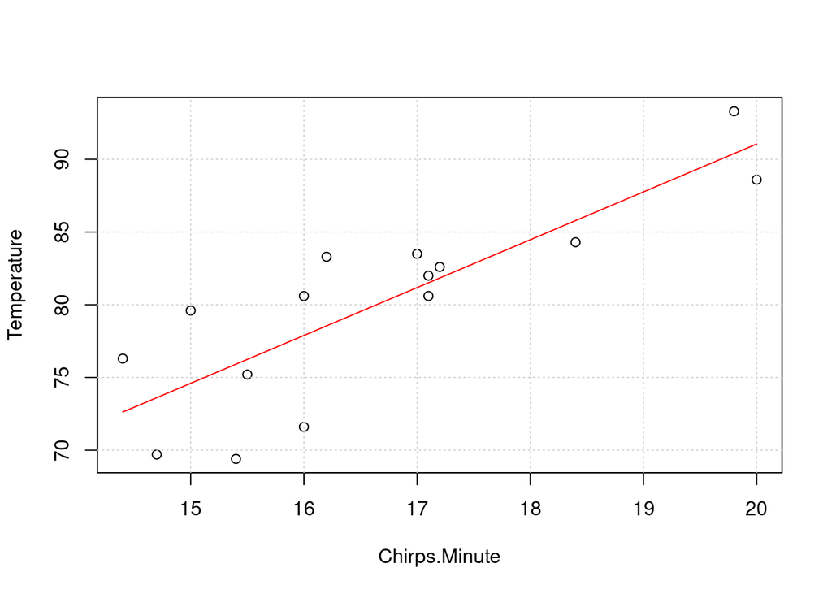

```r
plot(mydta)

grid()

lines(mydta[,1], predict(mylm), col=2)
```

## Generalisability

The regression themometer is likely to only be of use in places and time of the year similar to where the data were gathered. For example, this themometer would be useless in the UK.

# Next steps

Try to repeat this project by creating a new project in your workspace and typing and running the R script yourself.